# PSY 653 Module 2: Interaction Effects (aka Moderation)

Feb 5, 2020

Neil Yetz & Gemma Wallace

# Part 1: In-class Demo

Use the “moderation_demo.csv” datafile

## Load libraries

```r
library(psych)
library(tidyverse)
library(olsrr)
```

## Read in data

```r
dat <- read_csv("moderation_demo.csv")
```

## Get descriptives

```r
describe(dat)
```

|  | vars | n | mean | sd | median | trimmed | mad | min | max | range | skew | kurtosis | se |
| --- | --- | --- | --- | --- | --- | --- | --- | --- | --- | --- | --- | --- | --- |
| att1 | 1 | 692 | 1.140173 | 1.5185315 | 0 | 0.8826715 | 0.0000 | 0 | 9 | 9 | 1.8773352 | 5.138987 | 0.05772591 |
| att2 | 2 | 692 | 1.936416 | 0.8849950 | 2 | 1.8826715 | 1.4826 | 1 | 9 | 8 | 2.1378161 | 13.310467 | 0.03364246 |
| att3 | 3 | 692 | 1.479769 | 1.4429412 | 1 | 1.2960289 | 1.4826 | 0 | 9 | 9 | 2.7257621 | 11.573794 | 0.05485239 |
| att4 | 4 | 692 | 1.174855 | 1.3924764 | 1 | 0.9819495 | 1.4826 | 0 | 9 | 9 | 2.8786484 | 13.426460 | 0.05293401 |
| att5 | 5 | 692 | 1.261561 | 1.5119675 | 1 | 1.0559567 | 1.4826 | 0 | 9 | 9 | 1.0924979 | 1.185774 | 0.05747638 |
| group1 | 6 | 692 | 2.575145 | 1.1744337 | 2 | 2.5036101 | 1.4826 | 1 | 9 | 8 | 1.5592362 | 6.064636 | 0.04464527 |
| group2 | 7 | 692 | 1.592486 | 0.4917274 | 2 | 1.6155235 | 0.0000 | 1 | 2 | 1 | -0.3756223 | -1.861592 | 0.01869267 |
| out1 | 8 | 692 | 1.388728 | 1.4123868 | 2 | 1.3231047 | 0.0000 | 0 | 9 | 9 | 2.5669861 | 12.677424 | 0.05369089 |
| out2 | 9 | 692 | 1.210983 | 1.5476964 | 1 | 0.9657040 | 1.4826 | 0 | 9 | 9 | 2.9577076 | 12.165443 | 0.05883459 |
| out3 | 10 | 692 | 1.377168 | 1.4327972 | 2 | 1.2978339 | 0.0000 | 0 | 9 | 9 | 2.6228941 | 12.541761 | 0.05446678 |

[output cut: 1 more lines]

## Examine correlation between att1 & att3

```r
cor(dat$att1, dat$att3)
```

```
## [1] 0.04521701
```

Since the correlation between att1 and att3 is small, there is room for a moderation effect.

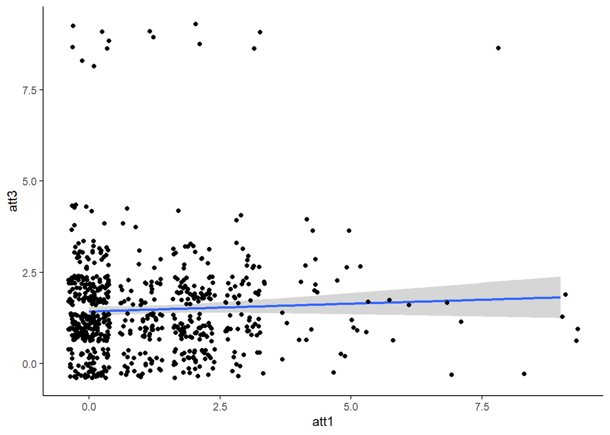

```r
ggplot(dat, aes(x = att1, y = att3)) +
  geom_smooth(method = "lm")+
  geom_jitter()+
  theme_classic()
```

## Create the cross product of att1 & att3

```r
dat <- mutate(dat, att1att3 = att1*att3)
```

## Run moderated regression in which att1, att3, and att1*att3 predict out4 ### Main Effects model

```r
modME <- lm(out4  ~ att1 + att3, data = dat)
ols_regress(modME)
```

```
##                         Model Summary
## --------------------------------------------------------------
## R                       0.453       RMSE                1.317
## R-Squared               0.206       Coef. Var          94.839
## Adj. R-Squared          0.203       MSE                 1.735
## Pred R-Squared          0.179       MAE                 0.905
## --------------------------------------------------------------
##  RMSE: Root Mean Square Error
##  MSE: Mean Square Error
##  MAE: Mean Absolute Error
##
##                                 ANOVA
## ---------------------------------------------------------------------
##                 Sum of
##                Squares         DF    Mean Square      F         Sig.
## ---------------------------------------------------------------------
## Regression     309.277          2        154.638    89.148    0.0000
## Residual      1195.156        689          1.735
## Total         1504.432        691
## ---------------------------------------------------------------------
##
##                                  Parameter Estimates
## --------------------------------------------------------------------------------------
##       model     Beta    Std. Error    Std. Beta      t        Sig      lower    upper
## --------------------------------------------------------------------------------------
## (Intercept)    0.655         0.080                  8.185    0.000     0.498    0.812
##        att1    0.049         0.033        0.050     1.480    0.139    -0.016    0.114
##        att3    0.458         0.035        0.448    13.190    0.000     0.390    0.527
## --------------------------------------------------------------------------------------
```

### Interaction model

```r
modINT <- lm(out4 ~ att1 + att3 + att1*att3 , data = dat)
ols_regress(modINT)
```

```
##                         Model Summary
## --------------------------------------------------------------
## R                       0.462       RMSE                1.311
## R-Squared               0.213       Coef. Var          94.435
## Adj. R-Squared          0.210       MSE                 1.720
## Pred R-Squared          0.176       MAE                 0.907
## --------------------------------------------------------------
##  RMSE: Root Mean Square Error
##  MSE: Mean Square Error
##  MAE: Mean Absolute Error
##
##                                 ANOVA
## ---------------------------------------------------------------------
##                 Sum of
##                Squares         DF    Mean Square      F         Sig.
## ---------------------------------------------------------------------
## Regression     321.154          3        107.051    62.243    0.0000
## Residual      1183.278        688          1.720
## Total         1504.432        691
## ---------------------------------------------------------------------
##
##                                   Parameter Estimates
## ---------------------------------------------------------------------------------------
##       model      Beta    Std. Error    Std. Beta      t        Sig      lower    upper
## ---------------------------------------------------------------------------------------
## (Intercept)     0.757         0.089                  8.539    0.000     0.583    0.931
##        att1    -0.032         0.045        0.041    -0.716    0.474    -0.121    0.056
##        att3     0.393         0.043        0.439     9.210    0.000     0.309    0.477
##   att1:att3     0.049         0.019        0.090     2.628    0.009     0.012    0.085
## ---------------------------------------------------------------------------------------
```

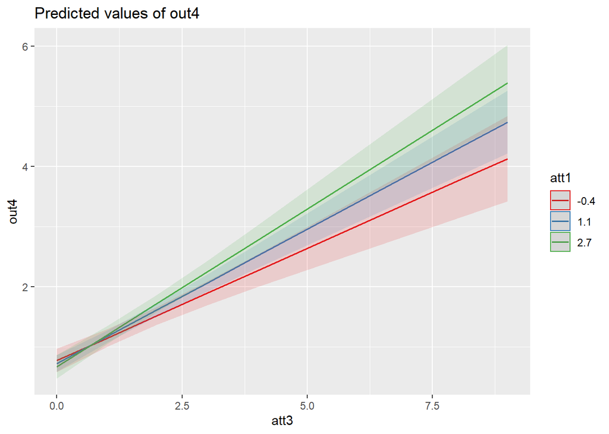

```r
library(sjPlot)
library(sjmisc)
plot_model(modINT, type = "pred", terms = c("att3", "att1"),
           show.intercept = TRUE, se = FALSE)
```

# Compare the two models

```r
anova(modME,modINT)
```

|  | Res.Df | RSS | Df | Sum of Sq | F | Pr(>F) |
| --- | --- | --- | --- | --- | --- | --- |
| 1 | 689 | 1195.156 | NA | NA | NA | NA |
| 2 | 688 | 1183.278 | 1 | 11.87723 | 6.905844 | 0.008783008 |

The model that includes the interaction effect accounts (modINT) for a significantly larger amount of variance in out4 compared to the model that only includes the main effects (modME) of the two predictors.

# Part 2: Try it yourself

Use the “moderation_sleepdata.csv” datafile In this exmaple, you will examine how sleep hygiene, anxiety, and the interaction between sleep hygiene and anxiety influence how well participants slept.

## Read in data

```r
sleep_data <- read_csv("moderation_sleepdata.csv")
```

## Get descriptives

```r
describe(sleep_data)
```

|  | vars | n | mean | sd | median | trimmed | mad | min | max | range | skew | kurtosis | se |
| --- | --- | --- | --- | --- | --- | --- | --- | --- | --- | --- | --- | --- | --- |
| age | 1 | 600 | 44.940000 | 12.8655524 | 45.200 | 45.124583 | 16.456860 | 20.00 | 67.80 | 47.80 | -0.09745994 | -1.13828406 | 0.52523398 |
| anxiety | 2 | 600 | 3.882450 | 0.9047863 | 3.860 | 3.892417 | 0.926625 | 1.05 | 6.84 | 5.79 | -0.07223473 | -0.06024914 | 0.03693775 |
| hygiene | 3 | 600 | 5.994133 | 1.5738213 | 6.050 | 6.037146 | 1.571556 | 1.68 | 9.74 | 8.06 | -0.23454564 | -0.28674288 | 0.06425098 |
| sleep | 4 | 600 | 68.876667 | 12.1397589 | 69.000 | 69.085417 | 11.860800 | 34.00 | 99.00 | 65.00 | -0.15727289 | -0.17457777 | 0.49560358 |
| lifesat | 5 | 600 | 4.056350 | 0.9155668 | 4.055 | 4.039875 | 0.956277 | 1.68 | 6.61 | 4.93 | 0.13308413 | -0.22525077 | 0.03737786 |

## Examine correlation between anxiety and hygiene

```r
cor(sleep_data$anxiety, sleep_data$hygiene)
```

```
## [1] 0.0888915
```

Since the correlation between the two variables is relatively small, there is room for a moderation effect

## Create the cross-product of hygiene and anxiety

```r
sleep_data <- mutate(sleep_data, anxiety_hygiene = hygiene*anxiety)
```

## Run moderated regression in which hygiene, anxiety, and hygiene*anxiety predict sleep ### Main effects model

```r
slp_mod1 <- lm(sleep  ~ hygiene + anxiety, data = sleep_data )
ols_regress(slp_mod1)
```

```
##                         Model Summary
## --------------------------------------------------------------
## R                       0.759       RMSE                7.915
## R-Squared               0.576       Coef. Var          11.491
## Adj. R-Squared          0.575       MSE                62.644
## Pred R-Squared          0.572       MAE                 6.245
## --------------------------------------------------------------
##  RMSE: Root Mean Square Error
##  MSE: Mean Square Error
##  MAE: Mean Absolute Error
##
##                                  ANOVA
## -----------------------------------------------------------------------
##                  Sum of
##                 Squares         DF    Mean Square       F         Sig.
## -----------------------------------------------------------------------
## Regression    50878.425          2      25439.213    406.092    0.0000
## Residual      37398.448        597         62.644
## Total         88276.873        599
## -----------------------------------------------------------------------
##
##                                   Parameter Estimates
## ----------------------------------------------------------------------------------------
##       model      Beta    Std. Error    Std. Beta      t        Sig      lower     upper
## ----------------------------------------------------------------------------------------
## (Intercept)    44.465         1.808                 24.596    0.000    40.915    48.016
##     hygiene     5.791         0.206        0.751    28.071    0.000     5.386     6.196
##     anxiety    -2.653         0.359       -0.198    -7.394    0.000    -3.358    -1.948
## ----------------------------------------------------------------------------------------
```

### Interaction model

```r
slp_mod2 <- lm(sleep  ~ hygiene + anxiety + anxiety_hygiene, data = sleep_data )
ols_regress(slp_mod2)
```

```
##                         Model Summary
## --------------------------------------------------------------
## R                       0.761       RMSE                7.893
## R-Squared               0.579       Coef. Var          11.459
## Adj. R-Squared          0.577       MSE                62.297
## Pred R-Squared          0.574       MAE                 6.225
## --------------------------------------------------------------
##  RMSE: Root Mean Square Error
##  MSE: Mean Square Error
##  MAE: Mean Absolute Error
##
##                                  ANOVA
## -----------------------------------------------------------------------
##                  Sum of
##                 Squares         DF    Mean Square       F         Sig.
## -----------------------------------------------------------------------
## Regression    51148.102          3      17049.367    273.681    0.0000
## Residual      37128.771        596         62.297
## Total         88276.873        599
## -----------------------------------------------------------------------
##
##                                     Parameter Estimates
## --------------------------------------------------------------------------------------------
##           model      Beta    Std. Error    Std. Beta      t        Sig      lower     upper
## --------------------------------------------------------------------------------------------
##     (Intercept)    33.424         5.604                  5.964    0.000    22.418    44.431
##         hygiene     7.587         0.887        0.984     8.550    0.000     5.844     9.329
##         anxiety     0.237         1.435        0.018     0.165    0.869    -2.580     3.055
## anxiety_hygiene    -0.468         0.225       -0.336    -2.081    0.038    -0.909    -0.026
## --------------------------------------------------------------------------------------------
```

## Compare the two models

```r
anova(slp_mod1,slp_mod2)
```

|  | Res.Df | RSS | Df | Sum of Sq | F | Pr(>F) |
| --- | --- | --- | --- | --- | --- | --- |
| 1 | 597 | 37398.45 | NA | NA | NA | NA |
| 2 | 596 | 37128.77 | 1 | 269.677 | 4.32892 | 0.03789654 |

At a significance threshold of p<0.05, the model that included the interaction effect (slp_mod2) explained a significantly larger amount of variance in sleep than the model that only tested the main effects of anxiety and sleep hygiene (slp_mod1).